*Abstract*

*Specify the biological question you are asking.*

Among the causes of the countless diseases that humans can suffer, genetic causes are ones of the most concerning because they are usually treatable but not fixable/curable and they can be transmitted to our offspring. However, genetic factors of diseases can vary from slight predispositions to totally letal mutations and rearrangements that lead to miscarriages even before the pregnancy is noticeable. When regarded in the Ohta’s nearly neutral theory of evolution context, we can consider that these extremely deleterious mutations, which are hardly ever detected nor reported, are in the lower tail of the distribution, and that the mutations inducing slight predispositions are in the slightly deletrious zone. Therefore, what we know as ‘genetic disease’ must be around the center of the deleterious mutations distribution.

From now on in this work, if there’s no further [clarification], we’ll consider as ‘mutations’ only those that are deleterious or slightly deleterious, and for simplification we assume that they affect a gene (although it is known that some deleterious mutations can affect other regions like enhancers or epigenetic targets).

The same mutation can be more or less severe depending on the gene that it affects, so we can assume that there are differences in the essentiality of the genes, and that any change can be more or less deleterious according to importance of the gene. Given two chromosomes of equal gene density, it would be more likely to have an extremely deleterious mutation in that with the larger number of important genes. That’s why we don’t expect chromosomes with a large proportion of important genes, but rather a random distribution of such genes.

In this context, the biological question is: are mutations causing diseases in fact evenly distributed across human chromosomes?

*Put the question in the form of a null hypothesis and alternate hypothesis.* *Variables selection*

The biological hypotheses (random distribution of important genes vs. chromosomes with a higher deleterious potential) can be tested using as an estimator of important genes the number of diseases that have been reported for each of the chromosomes. It is expected to be proportional to the number of genes in each chromosome, meaning that both measures will follow the same distribution. Therefore, our null statistical hypothesis is that the distribution of diseases across the chromosomes follows the same as the genes, and the alternate hypothesis is that some chromosomes have more (or less) diseases associated than the expected, thus the distributions are different.

*Design an experiment that controls or randomizes the confounding variables.*

Other confounding variables that can not be controlled are those related to the diseases; for instance rare diseases tend to be less studied that those that affect a wide portion of the population, or the studies are less reliable due to the sample size. In addition, not all kind of mutations, genes and chromosomes are equally easy to study. These factors can be partially randomized by having into account diseases with different amounts of knowledge associated.

*Based on the number of variables, the kinds of variables, the expected fit to the parametric assumptions, and the hypothesis to be tested, choose the best statistical test to use.*

We will have a list of number of observations (diseases) for each category in a nominal variable (chromosome), enough data to take a large sample (>100 observations, >5 observations per category), and we want to test the adequation of our data to an expected distribution, so in this case the best statistical test would be a Chi-square test of goodness-of-fit.[http://www.biostathandbook.com/chigof.html.] It is also expected a fitness to the parametric assumptions but it’s not mandatory in this test, so it won’t be confirmed.

*If possible, do a power analysis to determine a good sample size for the experiment.*

As our data is available before the study, a post hoc power analysis will be performed after the data acquisition and cleaning to determine the best sample size.

*Data acquisition*

```r
# BASIC TABLE

  link <- 'http://mscbioinformatics.uab.cat/base/documents/bioinformaticsintranet1718/summary_human_genome2015_10_18D22_6.txt'
  header<-read.table(link, nrows = 1, stringsAsFactors = F)

  # there is a missing column name, as we can see in https://www.ncbi.nlm.nih.gov/genome/51?genome_assembly_id=214366
  t<-read.table(link, skip = 1 , stringsAsFactors = F)
  colnames(t)<-c(  as.character(header[1:4]), "INSDC", as.character(header[5:12]))

  # Also, the last row has a typo
  t[26,2:13]<-c(as.character(t[26,3:13]), as.character(t[27,1]))
  t<-t[1:26,]

  # The variables are transformed to numeric
  t[,6:13]<-apply(t[,6:13], 2, function(x){
    x<-gsub(",","",x)
    as.numeric(x)
    })
```

```r
  # Only the needed data is selected
  t<-t[c(1:24),c("Name","Size_(Mb)", "Gene")]
  t$Name <- factor(t$Name,  levels = c(1:22, 'X', 'Y'))


# DISEASES

  t$Number_Diseases<-c(1638,1038,898,646,749,955,774,585,622,612,997,861,308,538,486,675,963,243,1035,427,172,374,848,54)

# EXON TOTAL LENGTH

  # Read table
  Basepairs<-read.table('Data/Exon_bases',skip=1, sep = ' ')
  colnames(Basepairs)<-c('Name', 'Total_Bases', 'Exon_Bases')
  Basepairs$Name<-sub('chr', '', Basepairs$Name)
  Basepairs$Name<-as.factor(Basepairs$Name)

  # Add to general table
  t<-merge(t, Basepairs[c(1:24),c(1,3)], by = 'Name', sort = FALSE)
```

*Examine the data to see if it meets the assumptions of the statistical test you chose (primarily normality and homoscedasticity for tests of measurement variables). If it doesn’t, choose a more appropriate test.*

Once we have our data, we make some basic descriptive analysis:

```r
# DESCRIPTIVE STATISTICS

  library(ggplot2)
  library(reshape2)
  library(gridExtra)

  # Summary statistics
  sapply(t[2:5], summary)
```

```
##         Size_(Mb) Gene Number_Diseases Exon_Bases
## Min.        46.71  577            54.0     271500
## 1st Qu.     82.54 1706           471.2    2508000
## Median     133.50 2218           660.5    3382000
## Mean       128.70 2242           687.4    3379000
## 3rd Qu.    162.20 2627           912.2    4268000
## Max.       249.00 5078          1638.0    8079000
```

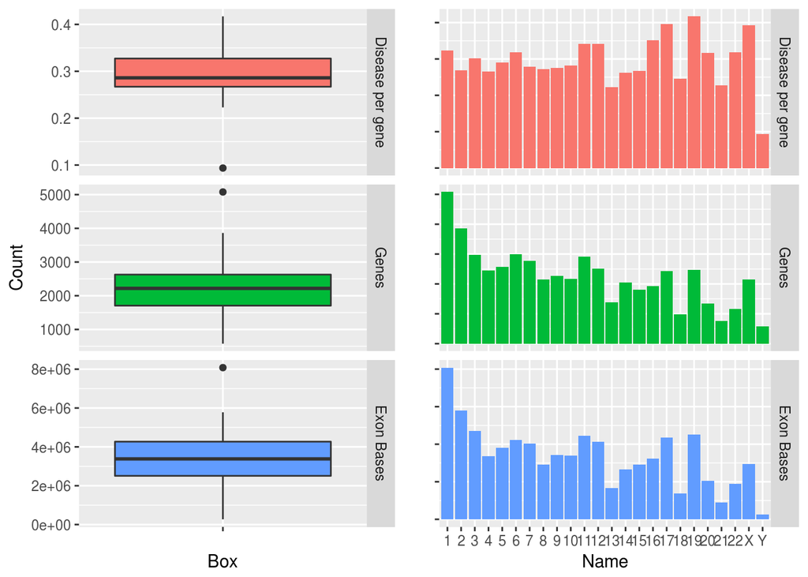

```r
  # Summary plots
  box<-data.frame(t$Name)
  colnames(box)<-'Name'
  box$`Disease per gene`<-t$Number_Diseases/t$Gene
  box$Genes <-t$Gene
  box$`Exon Bases`<-t$Exon_Bases
  box<-melt(box)
  bx<-ggplot(data = box, aes(x=factor(1), y=value, fill = variable, group = variable)) +
    geom_boxplot()+
    facet_grid(variable ~.,  scales = 'free')+
    xlab("Box")+
    ylab("Count")+
    theme(axis.text.x=element_text(colour = 'white'),legend.position="none")

  br<-ggplot(data = box, aes(x=Name, y=value, fill = variable, group = variable)) +
   geom_bar(stat = 'identity')+
    facet_grid (variable ~ . , scales = 'free')+
    ylab("")+
    theme(axis.text.y=element_blank(), legend.position="none")

  grid.arrange(bx, br, ncol = 2)
```

```r
  # ADEQUATION TO THE STATISTICAL TEST

  cor.test(t$Gene, t$Exon_Bases)
```

```
##
##  Pearson's product-moment correlation
##
## data:  t$Gene and t$Exon_Bases
## t = 23.722, df = 22, p-value < 2.2e-16
## alternative hypothesis: true correlation is not equal to 0
## 95 percent confidence interval:
##  0.9558909 0.9918818
## sample estimates:
##       cor
## 0.9810078
```

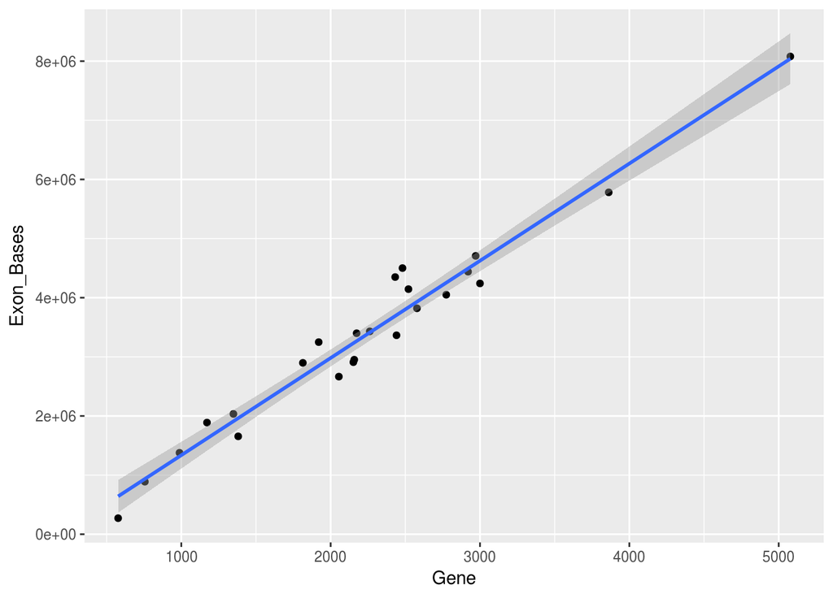

```r
  ggplot(t, aes(x = Gene, y = Exon_Bases))+
    geom_point()+
    geom_smooth(method = 'lm')
```

```r
  # POWER
  library(pwr)

  P0<-t$Gene/sum(t$Gene)
  P1<-t$Number_Diseases/sum(t$Number_Diseases)

  effect.size <- ES.w1(P0, P1)

  pwr.chisq.test(
               w=effect.size,
               N=NULL, # Total number of observations
               df=23,
               power=0.85,        # 1 minus Type II probability
               sig.level=0.01)    # Type I probability
```

```
##
##      Chi squared power calculation
##
##               w = 0.1712296
##               N = 1098.083
##              df = 23
##       sig.level = 0.01
##           power = 0.85
##
## NOTE: N is the number of observations
```

*Apply the statistical test you chose, and interpret the results.*

Now, the statistical test

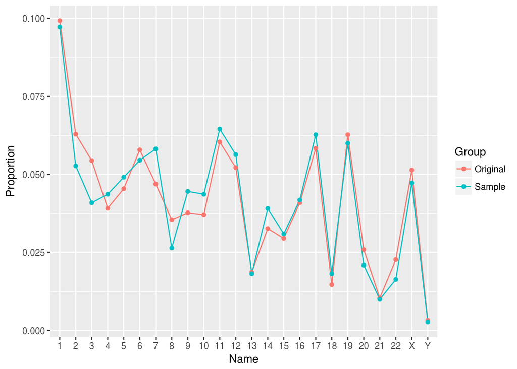

```r
# RESAMPLING

  # Original data numbers
  Resample<-data.frame(t$Name, t$Number_Diseases, rep('Original'), t$Number_Diseases/sum(t$Number_Diseases))
  colnames(Resample)<-c('Name', 'Diseases', 'Group', 'Proportion')

  # Simulation of the raw data
  population<-unlist(apply(t, 1, function(x){
    rep(x[1],x[4] )
  }))

  # Sample from the raw data
  Sample<-data.frame(table(sample(population, 1100, replace = FALSE)), rep('Sample'))
  colnames(Sample)<-c('Name', 'Diseases', 'Group')
  Sample$Proportion<-Sample$Diseases/sum(Sample$Diseases)
  Resample<-rbind(Resample, Sample)


  p<-ggplot(Resample, aes(x = Name, y = Proportion, color=Group, group = Group, line = Group))+geom_line()+geom_point()
  p
```

```r
# TEST Y has a very low number of observations, so it's deleted

  Observed<-Sample$Diseases[1:23]
  Expected<-t$Gene[1:23]
  Expected_Frq<-Expected/(sum(Expected))

  chisq.test(x=Observed, p =Expected_Frq)
```

```
##
##  Chi-squared test for given probabilities
##
## data:  Observed
## X-squared = 256.28, df = 22, p-value < 2.2e-16
```

```r
# NEW POWER

  P0<-Expected_Frq
  P1<-Observed/sum(Observed)

  effect.size <- ES.w1(P0, P1)

  pwr.chisq.test(
               w=effect.size,
               N=sum(Observed), # Total number of observations
               df=22,
               power=NULL,        # 1 minus Type II probability
               sig.level = 0.001)    # Type I probability
```

```
##
##      Chi squared power calculation
##
##               w = 0.4833411
##               N = 1097
##              df = 22
##       sig.level = 0.001
##           power = 1
##
## NOTE: N is the number of observations
```

```r
library(reshape2)
#
t$Gene_prop<-t$Gene/sum(t$Gene)
t$Dis_prop<-t$Number_Diseases/sum(t$Number_Diseases)
Pl<-melt(t[, c("Name", "Gene_prop", "Dis_prop")])
```

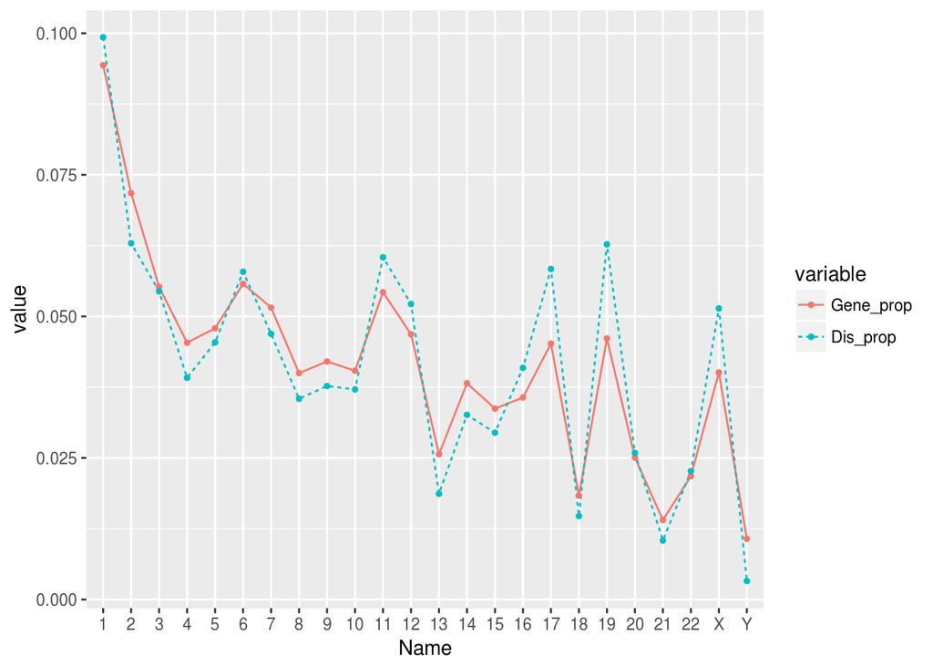

```r
ggplot(data=Pl, aes(x=Name, y=value, group=variable, color = variable, linetype=variable)) +
  geom_line()+
  geom_point( size=1)
```

*Communicate your results effectively, usually with a graph or table.*

*Sources*

Exon bases table source: HG19 http://seqanswers.com/forums/showthread.php?t=5298

Source NCBI: https://www.ncbi.nlm.nih.gov/pmc/articles/PMC3116565/

BARBADILLA - foto https://www.ncbi.nlm.nih.gov/pubmed/28270526